# Introduction to R

Priit Adler

2023-11-14

## Introduction (Rstudio / R)

You can find this and the data files from ELIXIREstonia github. [`https://github.com/ELIXIREstonia/2023-11-14-R-visualisation`](https://github.com/ELIXIREstonia/2023-11-14-R-visualisation).

R is a popular open-source programming language and environment for statistical computing and graphics.

RStudio is an integrated development environment (IDE) tailored for efficient and user-friendly R programming. Once launched, the RStudio UI presents itself in a segmented manner, primarily divided into four main panes.

- Text editor
- Console / Terminal / etc…
- Environment / History / Connections / Git
- Files / **Plots** / Packages / **Help** / etc…

see: [`https://rstudio.github.io/cheatsheets/html/rstudio-ide.html`](https://rstudio.github.io/cheatsheets/html/rstudio-ide.html) for more detailed overview.

### R Syntax and Basic Functions

```r
# Arithmetic operations
2 + 3
```

```
## [1] 5
```

```r
4 * 5
```

```
## [1] 20
```

```r
6 / 2 + 5 * 3
```

```
## [1] 18
```

```r
# Variables
x <- 10
y <- 20
x + y
```

```
## [1] 30
```

```r
# Functions
mean(c(1, 2, 3, 4, 5))
```

```
## [1] 3
```

```r
max(c(1, 2, 3, 4, 5))
```

```
## [1] 5
```

```r
# function with named arguments
my_sum <- function(a=NULL, b) {
  return(a + b)
}
my_sum(5, 7)
```

```
## [1] 12
```

### Data Structures in R

R has several data structures for organizing and storing data. Understanding these data structures is essential for effective data manipulation and analysis.

1. **Vectors**: A one-dimensional array of elements, all of the same data type. Vectors are commonly used for performing arithmetic operations and storing sequences of values.

```r
v <- c(1, 2, 3, 4, 5)
print(v)
```

```
## [1] 1 2 3 4 5
```

2. **Matrices**: A two-dimensional array of elements, organized in rows and columns, and all of the same data type. Matrices are useful for linear algebra operations and storing tabular data with a fixed number of rows and columns.

```r
m <- matrix(1:9, nrow = 3, ncol = 3)
print(m)
```

```
##      [,1] [,2] [,3]
## [1,]    1    4    7
## [2,]    2    5    8
## [3,]    3    6    9
```

3. **Data frames**: A two-dimensional table where each column can have a different data type. Data frames are the most common data structure for storing and manipulating tabular data in R, especially for statistical analysis.

```r
df <- data.frame(
  name = c("Alice", "Bob", "Charlie"),
  age = c(25, 30, 35),
  city = c("New York", "San Francisco", "Los Angeles")
)
print(df)
```

```
##      name age          city
## 1   Alice  25      New York
## 2     Bob  30 San Francisco
## 3 Charlie  35   Los Angeles
```

4. **Lists**: A versatile data structure that can store elements of different data types and structures, including vectors, matrices, data frames and other lists. Lists are useful for organizing and storing hierarchical or nested data.

```r
l <- list(
  name = "Alice",
  age = c(25, 30),
  city = c("New York", "San Francisco", "Los Angeles")
)
print(l)
```

```
## $name
## [1] "Alice"
##
## $age
## [1] 25 30
##
## $city
## [1] "New York"      "San Francisco" "Los Angeles"
```

Each data structure has its strengths and applications, and choosing the right one depends on the specific needs of your data manipulation and analysis tasks.

### Data Types in R

Understanding the fundamental data types in R is crucial for effective programming and data manipulation. Here’s an overview of the primary data types you’ll encounter in R:

1. **Numeric**: This is the default data type for numbers in R. Numeric types in R are essentially decimal (floating-point) numbers. They are used for most calculations involving numbers.

```r
num <- 42.5
print(num)
```

```
## [1] 42.5
```

2. **Integer**: Integers are numbers without decimal points. They can be explicitly defined by adding L to the end of the number.

```r
int_num <- 42L
print(int_num)
```

```
## [1] 42
```

3. **Character**: This type represents strings in R. Character strings are enclosed in quotes, either single (’) or double (“).

```r
str <- "Hello, World!"
print(str)
```

```
## [1] "Hello, World!"
```

4. **Logical**: This type, also known as Boolean, represents TRUE or FALSE values and is often the result of comparisons and logical operations.

```r
log_val <- TRUE
print(log_val)
```

```
## [1] TRUE
```

5. **Factor**: Factors are used to handle categorical data and store it as levels. They can be ordered or unordered and are particularly useful in statistical modeling.

```r
gender <- factor(c("Male", "Female", "Female", "Male"))
print(gender)
```

```
## [1] Male   Female Female Male
## Levels: Female Male
```

6. **Complex**: This data type is used for complex numbers with real and imaginary parts.

```r
complex_num <- 3 + 4i
print(complex_num)
```

```
## [1] 3+4i
```

7. **Raw**: The raw type is used to handle raw bytes. It’s less commonly used than the other data types but is important for certain types of binary data operations.

```r
raw_data <- charToRaw("Hello")
print(raw_data)
```

```
## [1] 48 65 6c 6c 6f
```

Each data type is suited for different kinds of tasks in R, and understanding these types is foundational for data analysis and programming in this environment. Choosing the correct data type is key to efficient programming and data processing in R.

## Loading the Tidyverse

```r
# Install tidyverse if not already installed
if (!requireNamespace("tidyverse", quietly = TRUE)) {
  install.packages("tidyverse")
}

# Load the tidyverse
library(tidyverse)
```

## Reading Data from a File

R supports a wide variety of file formats for reading and writing data. Some common formats include:

- CSV (Comma-Separated Values)
- TSV (Tab-Separated Values)
- Excel (XLS, XLSX)
- .. and few others

The `tidyverse` packages, such as `readr` and `readxl`, provide functions for reading data from many of these formats. In this workshop, we’ll focus on reading data from CSV, TSV.

### Reading CSV Data

```r
# Read data from a CSV file

data_csv <- read_csv("data/Islander_data.csv")

# Display the first few rows of the data
data_csv
```

[output not shown]

### Reading TSV Data

Remove `#` from second and last row to run example

```r
# Read data from a TSV file
# data_tsv <- read_tsv("data/Islander_data.tsv")

# Display the first few rows of the data
# head(data_tsv)
```

### Reading Excel Data

```r
# Install readxl package if not already installed
if (!requireNamespace("readxl", quietly = TRUE)) {
  install.packages("readxl")
}

# Load the readxl package
library(readxl)
```

Remove `#` from second and last row to run example

```r
# Read data from an Excel file
# data_excel <- read_excel("data/Islander_data.xlsx", sheet = "Sheet1")

# Display the first few rows of the data
# head(data_excel)
```

For the Excel file, you’ll need to remember to specify the correct sheet name using the `sheet` parameter in the `read_excel()` function.

## High-Level Overview of the Data with Tidyverse Pipes

Tidyverse pipes, represented by the `%>%` <ctrl+shift+M> symbol, allow you to chain together multiple functions in a clear and readable manner. Pipes take the output of one function and use it as the input for the next function, making it easy to follow the sequence of data transformations.

In the following example, we’ll use pipes to perform a series of operations on our dataset: 1. Group the data by a specific category (`group_by`) 2. Calculate summary statistics for each group (`summarize`) 3. Sort the resulting summary by a specific statistic (`arrange`)

```r
# Summarize the data
data_summary <- data %>%
  group_by(YourCategory) %>%
  summarize(
    mean_value = mean(YourVariable, na.rm = TRUE),
    n = n()
  ) %>%
  arrange(desc(mean_value))

head(data_summary)
```

```
## # A tibble: 5 × 3
##   YourCategory mean_value     n
##   <fct>             <dbl> <int>
## 1 B                  50.7    25
## 2 A                  50.0    20
## 3 C                  49.6    11
## 4 E                  49.1    24
## 5 D                  46.5    20
```

In the above code, replace `YourCategory` and `YourVariable` with the appropriate column names from your dataset. This will give a high-level overview of the data, summarizing it by the specified category and calculating the mean of the specified variable. The use of pipes makes it easy to understand the sequence of transformations applied to the data.

Find more options from [data-wrangling-cheatsheet](https://www.rstudio.com/wp-content/uploads/2015/02/data-wrangling-cheatsheet.pdf)

### Task:

**Task: Analyzing Effects of Drugs on Memory**

Using the “Memory Test on Drugged Islanders Data” dataset, your task is to analyze the effects of the different drugs and their dosages on memory recall.

1. **Data Exploration**:
   - Display the first 10 rows of the dataset.
   - Calculate the overall average of memory scores before and after the drug was administered.
2. **Drug Analysis**:
   - Using tidyverse pipes and the provided example as a reference, group the data by the **`Drug`** column.
   - For each drug, calculate:
     1. The average **`diff`** in memory scores.
     2. The total number of participants that took that drug (**`n()`**).
   - Sort the results based on the average **`diff`** in descending order.
3. **Dosage Analysis**:
   - Group the data by both **`Drug`** and **`dosage`**.
   - For each drug and dosage combination, calculate the average **`diff`** in memory scores.
   - Display the results, sorting first by **`Drug`** and then by the average **`diff`** in descending order.
4. **Age Group Analysis**:
   - Create a new column in the dataset called **`age_group`**. Categorize participants as “Young” if they are below 30, “Middle-aged” if they are between 30 and 50, and “Senior” if they are above 50. (*hint:* `case_when`)
   - Group the data by **`age_group`** and **`Drug`**.
   - Calculate the average **`diff`** in memory scores for each age group and drug combination.
   - Display the results, and try to infer if age has any impact on the drug’s effectiveness.
5. **Happy/Sad Group Analysis**:
   - Group the data based on the **`happy/sad group`** column.
   - For each emotion group, calculate the average **`diff`** in memory scores before and after drug administration.
   - Compare the results. Does the primed emotion seem to have an effect on the memory scores?

# About the data

In examples we’ll be using a [Kaggle](https://www.kaggle.com/datasets/steveahn/memory-test-on-drugged-islanders-data?resource=download) “**Memory Test on Drugged Islanders Data**” dataset.

**Dataset description**

An experiment on the effects of anti-anxiety medicine on memory recall when being primed with happy or sad memories. The participants were done on novel Islanders whom mimic real-life humans in response to external factors.

Drugs of interest (known-as) [Dosage 1, 2, 3]:

A - Alprazolam (Xanax, Long-term) [1mg/3mg/5mg]

T - Triazolam (Halcion, Short-term) [0.25mg/0.5mg/0.75mg]

S- Sugar Tablet (Placebo) [1 tab/2tabs/3tabs]

The easiest way to read in the data is to use `read_csv` command:

```r
Isd <- read_csv('data/Islander_data.csv')
Isd
```

```
## # A tibble: 198 × 9
##    first_name last_name   age Happy_Sad_group Dosage Drug  Mem_Score_Before
##    <chr>      <chr>     <dbl> <chr>            <dbl> <chr>            <dbl>
##  1 Bastian    Carrasco     25 H                    1 A                 63.5
##  2 Evan       Carrasco     52 S                    1 A                 41.6
##  3 Florencia  Carrasco     29 H                    1 A                 59.7
##  4 Holly      Carrasco     50 S                    1 A                 51.7
##  5 Justin     Carrasco     52 H                    1 A                 47
##  6 Liam       Carrasco     37 S                    1 A                 66.4
##  7 Ava        Durand       35 S                    1 A                 44.1
##  8 Jamie      Durand       38 H                    1 A                 76.3
##  9 Josefa     Durand       29 H                    1 A                 56.2
## 10 Mark       Durand       36 S                    1 A                 54.8
## # ℹ 188 more rows
## # ℹ 2 more variables: Mem_Score_After <dbl>, Diff <dbl>
```

# Plotting with ggplot2

The ggplot2 package in R follows a modular paradigm based on the “Grammar of Graphics.” This modular approach allows users to build complex plots by combining simple components or layers. Each layer represents a specific element of the plot, such as data, aesthetics, geoms, scales, and themes.

1. **Data**: This is the foundation of any plot. You specify the dataset you want to visualize.
2. **Aesthetics**: Aesthetics are the visual properties of the plot, such as x and y position, color, size, shape, and transparency. You map variables in the dataset to these aesthetics, creating a relationship between the data and the plot elements.
3. **Geoms**: Geoms (short for geometric objects) are the actual plot elements, such as points, lines, and bars. Different geoms represent different types of plots, like scatter plots, line plots, or bar plots. You can add multiple geoms to a single plot to create complex visualizations.
4. **Scales**: Scales control how data values are mapped to aesthetic properties. They define the transformation and mapping of data values to visual properties, such as colors, sizes, or shapes. You can adjust scales to customize the appearance of the plot.
5. **Themes**: Themes control the non-data aspects of the plot, such as the background, gridlines, axis labels, and legend. You can customize the plot’s appearance by changing its theme.

In the ggplot2 modular paradigm, you start by specifying the data and the aesthetics, then add geoms, scales, and themes as needed. This layer-by-layer approach allows you to create a wide range of plots by combining and customizing these components.

Here’s an example that demonstrates the modular paradigm:

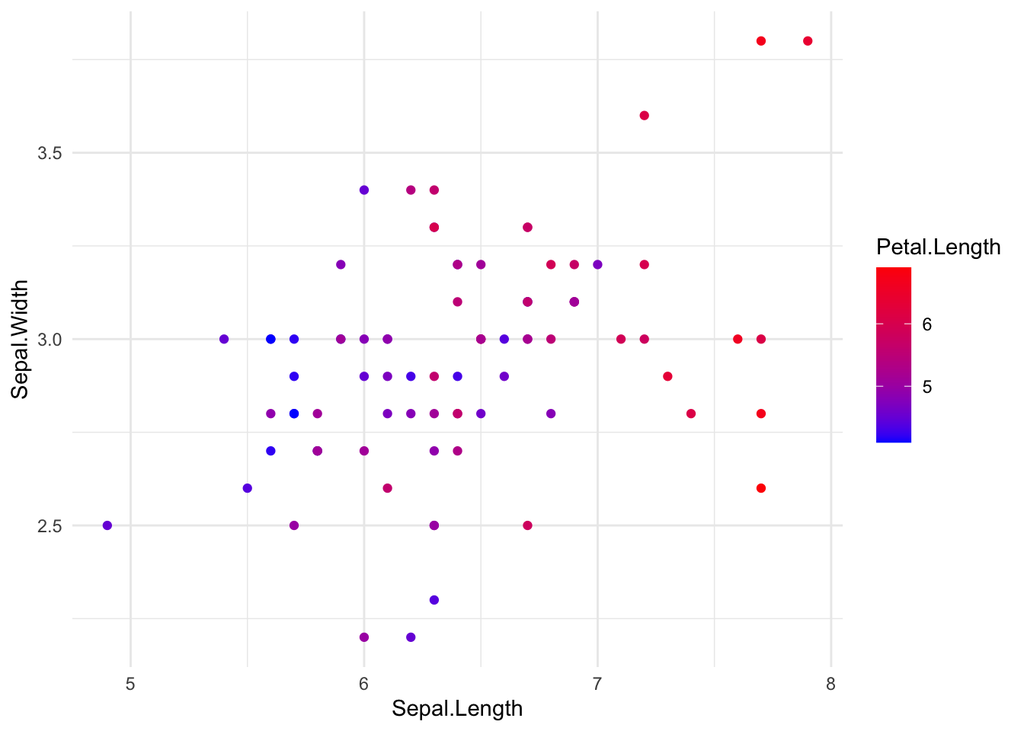

```r
# Define data and aesthetics
plot <- ggplot(data = iris %>% filter(Petal.Length > 4), aes(x = Sepal.Length, y = Sepal.Width, color = Petal.Length)) +
  geom_point() +
  scale_color_continuous(low = "blue", high = "red") +
  theme_minimal()

# Display the final plot
plot
```

## Aesthetics in ggplot2

Aesthetics are the visual properties of the elements in a plot. They help convey the underlying patterns and relationships in the data. In ggplot2, you map variables from your dataset to aesthetics to create a relationship between the data and the plot elements. Common aesthetics include `x` and `y` position, `color`, `size`, `shape`, `group`, and `transparency`.

### Mapping Aesthetics

Let’s create a scatter plot with the `age` variable mapped to the x-axis, the `Diff` variable mapped to the y-axis, and the `Drug` variable mapped to the color aesthetics:

```r
Isd <- read_csv('data/Islander_data.csv')
```

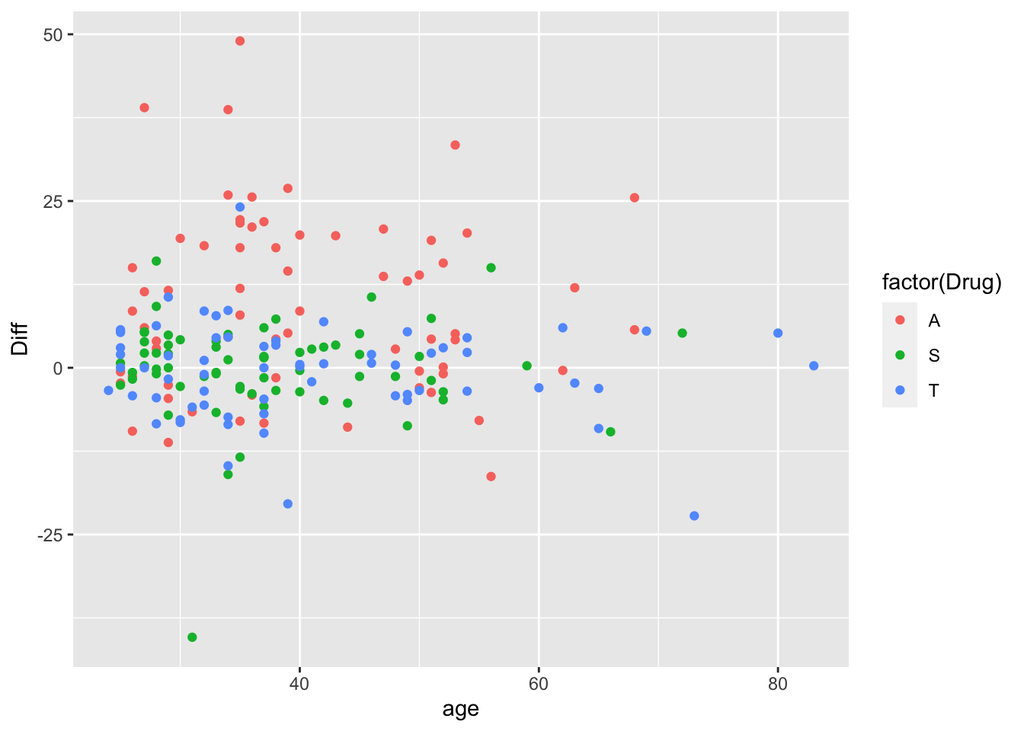

```r
# Create a scatter plot with aesthetics mapped to variables
scatter_plot <- ggplot(Isd, aes(x = age, y = Diff, color = factor(Drug))) +
  geom_point()

scatter_plot
```

### Modifying Aesthetic Properties and Overwriting in Geoms

You can modify aesthetic properties directly within a geom. This allows you to make specific adjustments to the appearance of individual plot elements. Let’s create a scatter plot with larger points and a custom transparency:

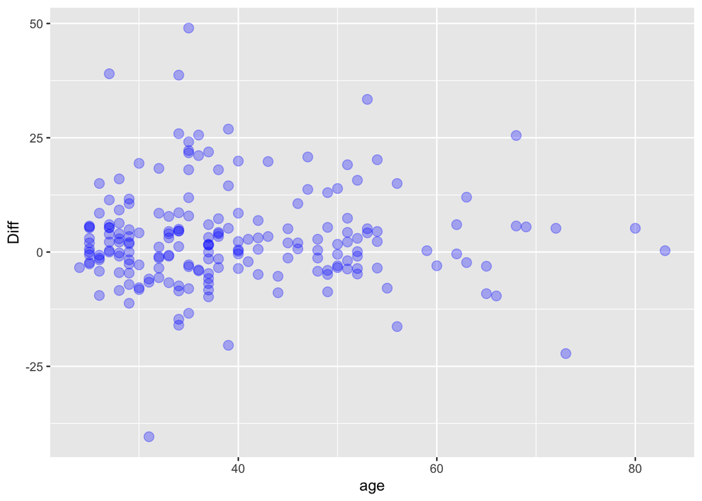

```r
# Modify the size and transparency of points within the geom
scatter_plot_independent_aes <- ggplot(Isd, aes(x = age, y = Diff)) +
  geom_point(size = 3, alpha = 0.3, color='blue')

scatter_plot_independent_aes
```

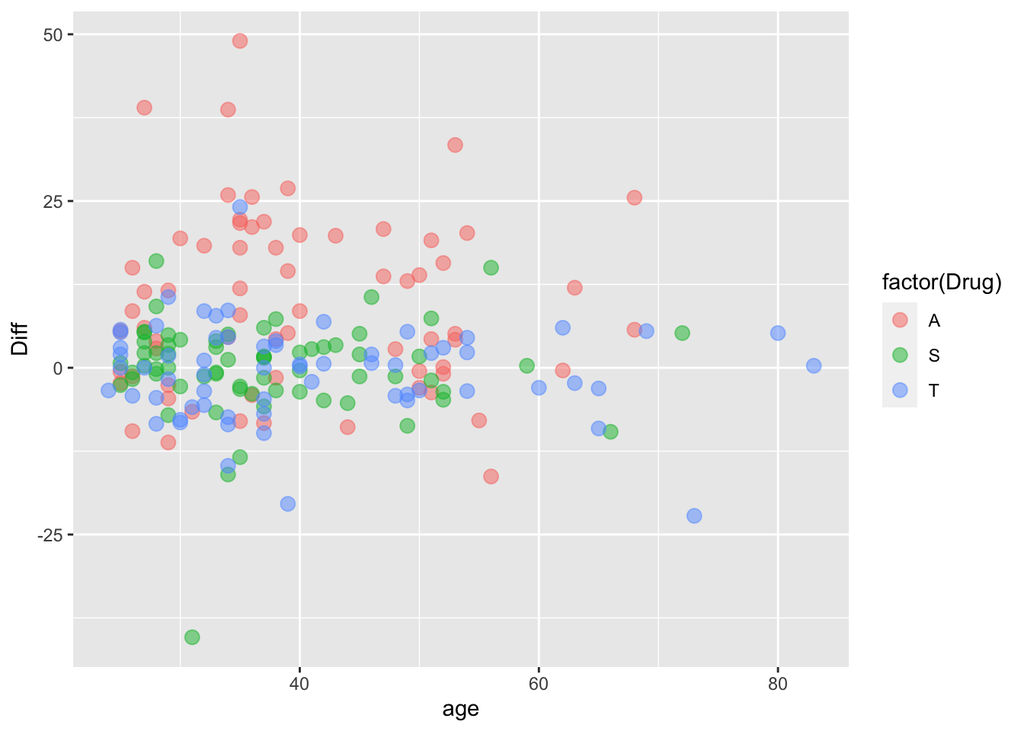

```r
scatter_plot_data_related_aes <- ggplot(Isd, aes(x = age, y = Diff)) +
  geom_point(size = 3, alpha = 0.5, aes(color = factor(Drug)))

scatter_plot_data_related_aes
```

In this example, we have increased the size of the points and made them semi-transparent by setting the `size` and `alpha` arguments within the `geom_point()` function, respectively. By modifying aesthetics directly within a geom, you can overwrite the initial mappings created by the `aes()` function and gain more control over the appearance of your plot elements.

## Exploring Different Geom Selections

In this section, we will demonstrate various geom selections using simple dummy data. Each geom represents a specific type of plot, and their applicability depends on the type of data (numeric vs. categorical) and the relationship you want to visualize.

### Scatterplot (geom_point)

A scatterplot displays the relationship between two numeric variables by plotting points at their respective x and y coordinates. It’s useful for visualizing trends, patterns, or outliers in the data.

```r
# Use Islander dataset as an example
head(Isd)
```

```
## # A tibble: 6 × 9
##   first_name last_name   age Happy_Sad_group Dosage Drug  Mem_Score_Before
##   <chr>      <chr>     <dbl> <chr>            <dbl> <chr>            <dbl>
## 1 Bastian    Carrasco     25 H                    1 A                 63.5
## 2 Evan       Carrasco     52 S                    1 A                 41.6
## 3 Florencia  Carrasco     29 H                    1 A                 59.7
## 4 Holly      Carrasco     50 S                    1 A                 51.7
## 5 Justin     Carrasco     52 H                    1 A                 47
## 6 Liam       Carrasco     37 S                    1 A                 66.4
## # ℹ 2 more variables: Mem_Score_After <dbl>, Diff <dbl>
```

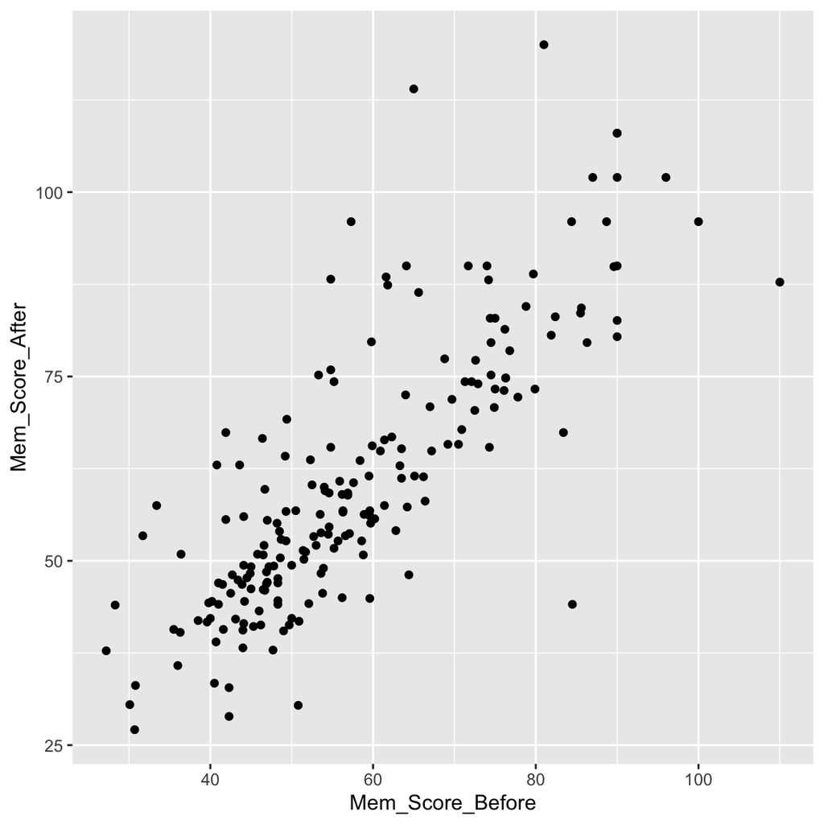

```r
# Create a scatterplot of memory score before vs memory score after taking the drug
scatter_plot <- ggplot(Isd, aes(x = Mem_Score_Before, y = Mem_Score_After)) +
  geom_point()

scatter_plot
```

### Line Plot (geom_line)

A line plot connects data points with lines to visualize the relationship between two numeric variables. It’s useful for showing trends over time or any continuous variable.

```r
# Use the pressure dataset as an example
head(pressure)
```

```
##   temperature pressure
## 1           0   0.0002
## 2          20   0.0012
## 3          40   0.0060
## 4          60   0.0300
## 5          80   0.0900
## 6         100   0.2700
```

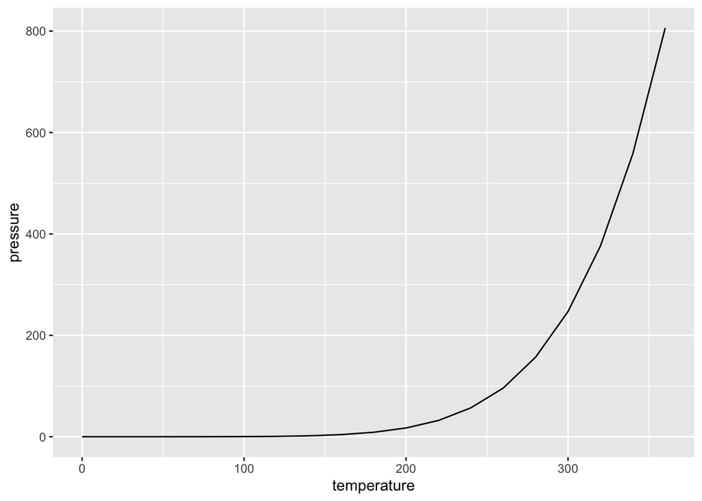

```r
# Create a line plot of temperature vs. pressure
line_plot <- ggplot(pressure, aes(x = temperature, y = pressure)) +
  geom_line()

line_plot
```

### Bar Plot (geom_bar) and Column Plot (geom_col)

A bar plot displays the frequency or count of categorical data, while a column plot displays the value of a numeric variable for each category. Both are useful for visualizing relationships between categorical and numeric variables.

```r
# Use Islander dataset as an example
head(Isd)
```

```
## # A tibble: 6 × 9
##   first_name last_name   age Happy_Sad_group Dosage Drug  Mem_Score_Before
##   <chr>      <chr>     <dbl> <chr>            <dbl> <chr>            <dbl>
## 1 Bastian    Carrasco     25 H                    1 A                 63.5
## 2 Evan       Carrasco     52 S                    1 A                 41.6
## 3 Florencia  Carrasco     29 H                    1 A                 59.7
## 4 Holly      Carrasco     50 S                    1 A                 51.7
## 5 Justin     Carrasco     52 H                    1 A                 47
## 6 Liam       Carrasco     37 S                    1 A                 66.4
## # ℹ 2 more variables: Mem_Score_After <dbl>, Diff <dbl>
```

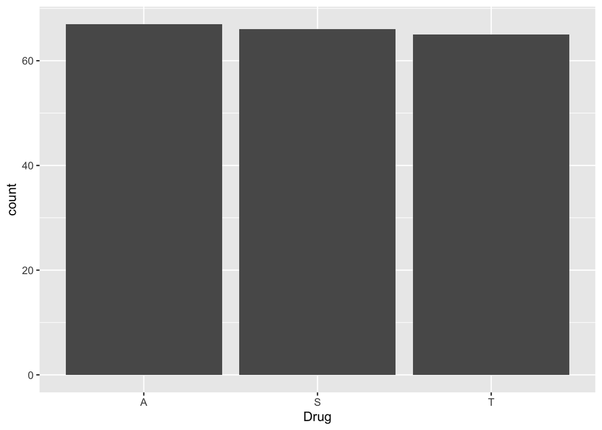

```r
# on categorical data, count how many instances of each appears in the data
bar_plot <- ggplot(Isd, aes(x = Drug)) +
  geom_bar()

bar_plot
```

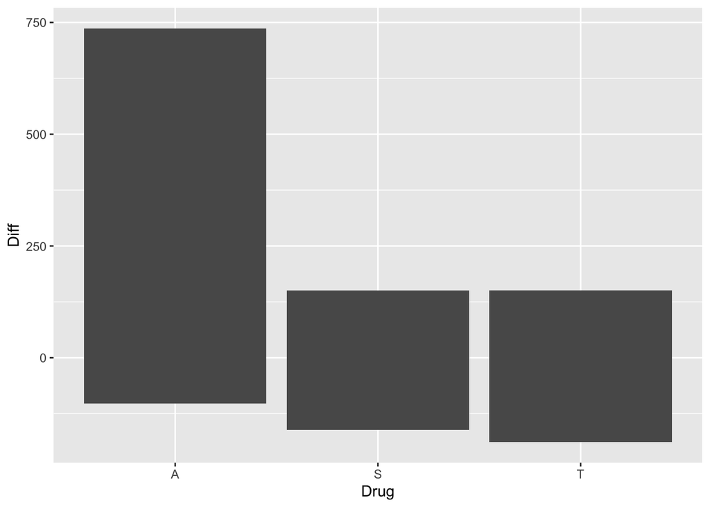

```r
# on numerical data (y-axis) sum up all values, relative to x axis categories
column_plot <- ggplot(Isd, aes(x = Drug, y = Diff)) +
  geom_col()

column_plot
```

### Histogram (geom_histogram)

A histogram groups numeric data into bins and displays the frequency of observations in each bin. It’s useful for visualizing the distribution of a numeric variable.

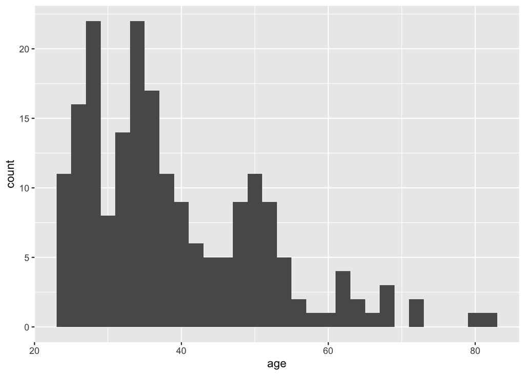

```r
# Create a histogram of the mpg variable from the mtcars dataset
histogram_plot <- ggplot(Isd, aes(x = age)) +
  geom_histogram(binwidth = 2)

histogram_plot
```

### Box Plot (geom_boxplot)

A box plot displays the distribution of a numeric variable across different categories. It’s useful for comparing distributions and identifying outliers within categorical groups.

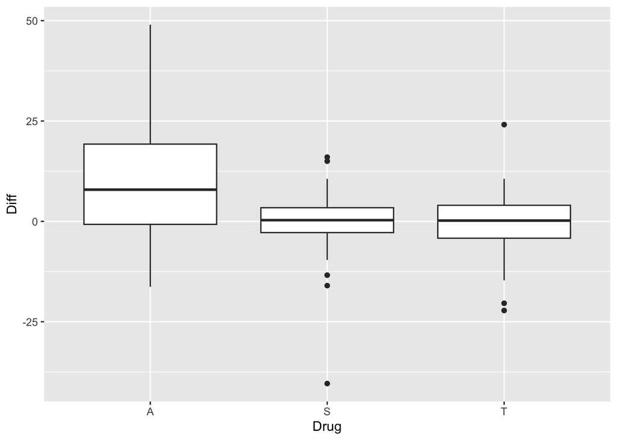

```r
# Create a box plot of price by cut for the diamonds dataset
box_plot <- ggplot(Isd, aes(x = Drug, y = Diff)) +
  geom_boxplot()

box_plot
```

These are just a few examples of the many `geoms` available in ggplot2. By selecting the appropriate geom for your data, you can create informative and visually appealing plots that effectively communicate the relationships within your dataset.

## Position Adjustments and Adding Multiple Layers

### Jittering Points (position = “jitter”)

In scatter plots, data points can sometimes overlap, making it difficult to discern individual observations. To address this issue, you can apply a position adjustment, such as `jitter`, which slightly moves the points in a random direction to reduce overlap.

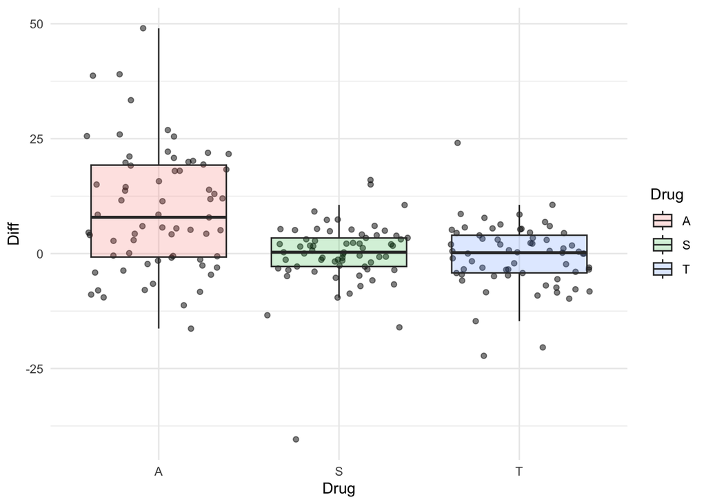

```r
jittered_plot <- ggplot(Isd, aes(x = Drug, y = Diff)) +
  geom_point(position = position_jitter(width = 0.4), alpha = 0.5) +
  geom_boxplot(aes(fill = Drug), alpha = 0.2, outlier.shape = NA) +
  theme_minimal()

jittered_plot
```

### Adding Multiple Layers (Geoms)

You can add multiple `geoms` to a single plot to create more complex visualizations. For example, you can combine a scatter plot with a smoothed line to show the overall trend, and add text labels to annotate specific data points.

```r
# Use the mtcars dataset as an example
head(mtcars)
```

```
##                    mpg cyl disp  hp drat    wt  qsec vs am gear carb
## Mazda RX4         21.0   6  160 110 3.90 2.620 16.46  0  1    4    4
## Mazda RX4 Wag     21.0   6  160 110 3.90 2.875 17.02  0  1    4    4
## Datsun 710        22.8   4  108  93 3.85 2.320 18.61  1  1    4    1
## Hornet 4 Drive    21.4   6  258 110 3.08 3.215 19.44  1  0    3    1
## Hornet Sportabout 18.7   8  360 175 3.15 3.440 17.02  0  0    3    2
## Valiant           18.1   6  225 105 2.76 3.460 20.22  1  0    3    1
```

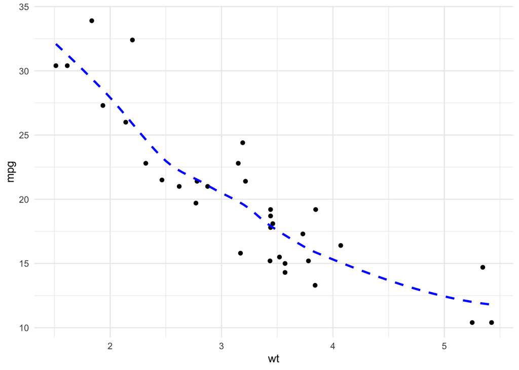

```r
# Create a scatter plot of mpg (miles per gallon) vs. wt (weight) with a smoothed line
scatter_plot_smooth <- ggplot(mtcars, aes(x = wt, y = mpg)) +
  geom_point() +
  geom_smooth(formula = y ~ x, method = "loess", se = FALSE, linetype = "dashed", color = "blue") +
  theme_minimal()

scatter_plot_smooth
```

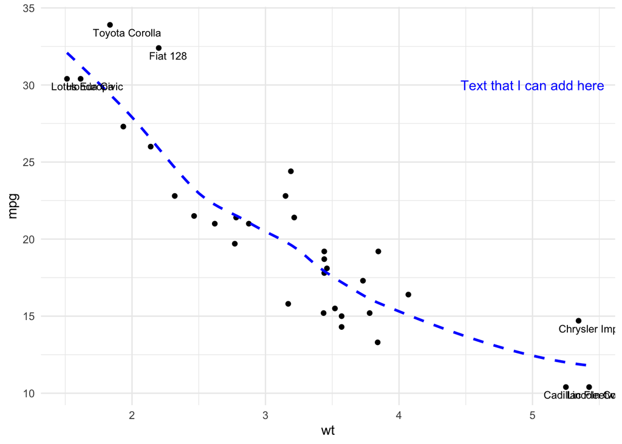

```r
# Annotate specific data points with text labels
scatter_plot_annotate <- scatter_plot_smooth +
  geom_text(data = subset(mtcars, mpg > 30 | wt > 5),
            size = 3, hjust = 0.25, vjust = 1.5,
            mapping = aes(label=rownames(subset(mtcars, mpg > 30 | wt > 5)))) +
  annotate(geom = 'text', x = 5, y = 30, label="Text that I can add here", color="blue")

scatter_plot_annotate
```

In this example, we first created a scatter plot of `mpg` vs. `wt` and added a smoothed line using `geom_smooth`. Then, we annotated specific data points with text labels using `geom_text`. By combining multiple `geoms`, you can create more informative and visually appealing plots.

### Task:

Use the cell below to repeat the steps we have done so far. Generate a plot where you show `Islander_data` data by `Drug` and `Diff`. Use `geom_violin`, what does it show and how to interpret it? Add `geom_point` to there as well, make it very light (transparent), use position `jitter`. Find more options from [data-wrangling-cheatsheet](https://www.rstudio.com/wp-content/uploads/2015/02/data-wrangling-cheatsheet.pdf)

## Scaling Numeric and Discrete Variables

Scaling variables allows you to transform their range, making it easier to visualize data that spans multiple orders of magnitude or to compare multiple variables with different units.

### Scaling Numeric Variables

For numeric variables, you can use scale_x_continuous() and scale_y_continuous() to adjust the scales of the x and y axes. The mtcars dataset, which is built into R, provides a great example for demonstrating this.

Example: Log Transformation of Horsepower Let’s create a scatter plot of miles per gallon (mpg) vs. horsepower (hp) and scale the y axis using log transformations:

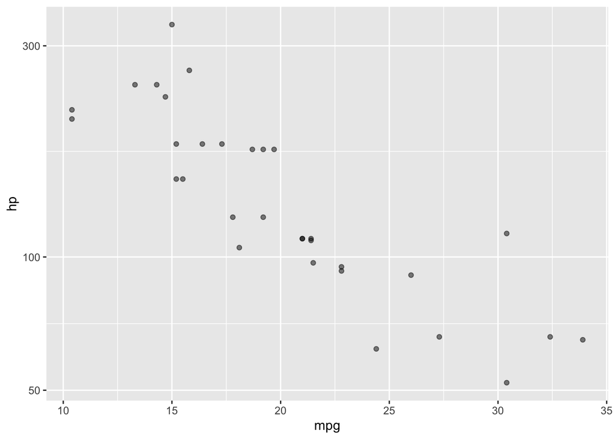

```r
# Scatter plot with log-scaled y-axis using mtcars data
scatter_plot_scaled <- ggplot(mtcars, aes(x = mpg, y = hp)) +
  geom_point(alpha = 0.5) +
  scale_y_continuous(trans = "log10")

scatter_plot_scaled
```

In this example, using log transformations to scale the horsepower helps reveal patterns in the relationship between fuel efficiency (mpg) and engine power (hp) that might not be apparent with the original scales.

### Scaling Discrete Variables

For discrete variables, you can use scale_x_discrete() and scale_y_discrete() to modify the order or appearance of the categories. With mtcars, we can explore how the number of cylinders (cyl) in a car affects its fuel efficiency (mpg).

Example: Reordering Cylinder Categories by Median MPG Let’s create a box plot of the number of cylinders vs. mpg and reorder the cylinder categories based on their median mpg:

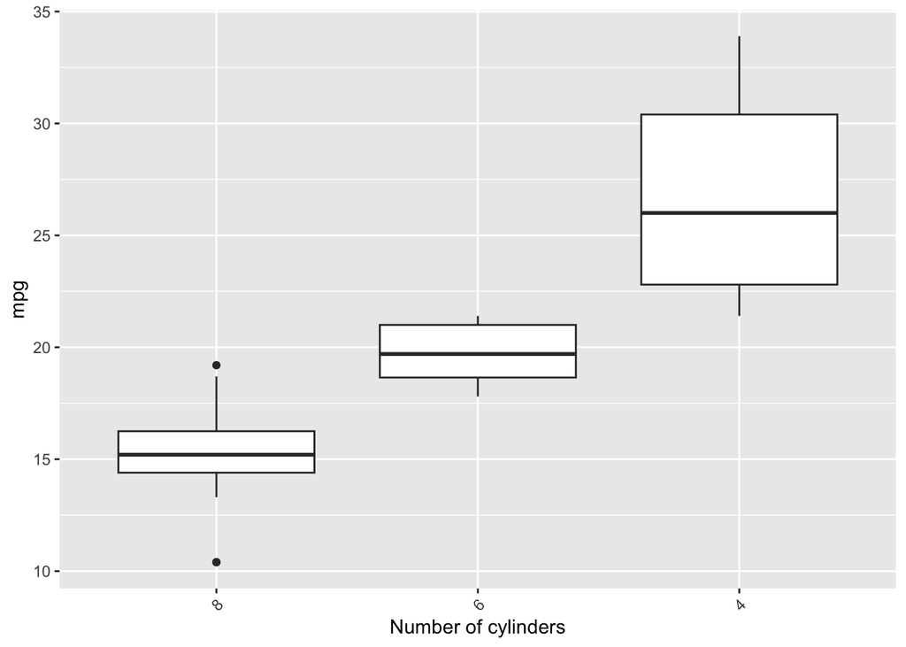

```r
# Calculate the median mpg for each cylinder category
cyl_median <- mtcars %>%
  group_by(cyl) %>%
  summarize(median_mpg = median(mpg, na.rm = TRUE)) %>%
  arrange(median_mpg)

# Create a box plot with reordered cylinder categories
box_plot_scaled <- ggplot(mtcars, aes(x = factor(cyl), y = mpg)) +
  geom_boxplot() +
  scale_x_discrete(limits = factor(cyl_median$cyl)) +
  theme(axis.text.x = element_text(angle = 45, hjust = 1)) +
  xlab('Number of cylinders')

box_plot_scaled
```

In this example, reordering the number of cylinders based on the median miles per gallon helps highlight differences in fuel efficiency across different engine sizes. This makes it easier to compare the fuel efficiency of cars with varying numbers of cylinders.

Scaling variables can enhance the readability of your plots and reveal hidden patterns in your data. By applying appropriate transformations to numeric and discrete variables, you can create more effective visualizations.

## Color Scaling

Color scaling can be used to visualize an additional variable in a plot, adding an extra dimension of information. In this revised example, we’ll create a box plot of the number of cylinders (**`cyl`**) vs. miles per gallon (**`mpg`**), with the color of the points representing engine displacement (**`disp`**).

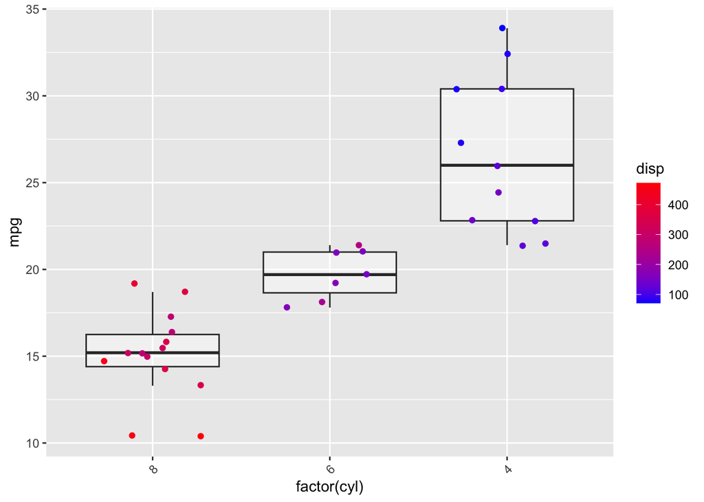

```r
# Create a box plot with reordered cylinder categories and color scaling
box_plot_color_scaled <- ggplot(mtcars, aes(x = factor(cyl), y = mpg)) +
  geom_boxplot(alpha = 0.4, outlier.shape = NA) +  # fill based on disp
  geom_jitter(aes(color = disp), width = 0.3) +  # jitter points colored by disp
  scale_x_discrete(limits = factor(cyl_median$cyl)) +
  scale_color_gradient(low = "blue", high = "red") +  # gradient color for jitter points
  theme(axis.text.x = element_text(angle = 45, hjust = 1))

box_plot_color_scaled
```

By applying color scaling, you create richer visualizations that display more information and enhance the understanding of your data. This technique is particularly useful in exploring and presenting complex relationships in a dataset.

## Refactoring and Reordering Factorial Data

Factor variables are categorical variables that can take a limited number of distinct values. In ggplot2, you can refactor and reorder factor variables to enhance your visualizations.

### Refactoring

Refactoring involves changing the levels of a factor variable. You can use the `forcats` package (part of the tidyverse) to refactor variables. The `fct_recode()` function can be used to recode the levels of a factor.

```r
# Load the required packages
# library(forcats)

# # Recode the Drug variable
Isd_refactored <- Isd %>%
  mutate(Drug_name = fct_recode(Drug,
                                "Alprazolam" = "A",
                                "Triazolam" = "T",
                                "Sugar" = "S"))

head(Isd_refactored)
```

```
## # A tibble: 6 × 10
##   first_name last_name   age Happy_Sad_group Dosage Drug  Mem_Score_Before
##   <chr>      <chr>     <dbl> <chr>            <dbl> <chr>            <dbl>
## 1 Bastian    Carrasco     25 H                    1 A                 63.5
## 2 Evan       Carrasco     52 S                    1 A                 41.6
## 3 Florencia  Carrasco     29 H                    1 A                 59.7
## 4 Holly      Carrasco     50 S                    1 A                 51.7
## 5 Justin     Carrasco     52 H                    1 A                 47
## 6 Liam       Carrasco     37 S                    1 A                 66.4
## # ℹ 3 more variables: Mem_Score_After <dbl>, Diff <dbl>, Drug_name <fct>
```

In this example, we refactored the `Drug` variable by changing the levels from letters to active drug names.

### Reordering

Reordering involves changing the order of the levels of a factor variable. You can use the `fct_reorder()` function to reorder the levels of a factor based on the values of another variable.

```r
# Create a new column with reordered genre based on the median intgross
Isd_reordered <- Isd_refactored %>%
  mutate(Drug_reordered = fct_reorder(Drug_name, Diff, .fun = max, .desc = TRUE))

head(Isd_reordered)
```

```
## # A tibble: 6 × 11
##   first_name last_name   age Happy_Sad_group Dosage Drug  Mem_Score_Before
##   <chr>      <chr>     <dbl> <chr>            <dbl> <chr>            <dbl>
## 1 Bastian    Carrasco     25 H                    1 A                 63.5
## 2 Evan       Carrasco     52 S                    1 A                 41.6
## 3 Florencia  Carrasco     29 H                    1 A                 59.7
## 4 Holly      Carrasco     50 S                    1 A                 51.7
## 5 Justin     Carrasco     52 H                    1 A                 47
## 6 Liam       Carrasco     37 S                    1 A                 66.4
## # ℹ 4 more variables: Mem_Score_After <dbl>, Diff <dbl>, Drug_name <fct>,
## #   Drug_reordered <fct>
```

Now let’s create a bar plot of the reordered Drug_reordered with the refactored Drug_name variable:

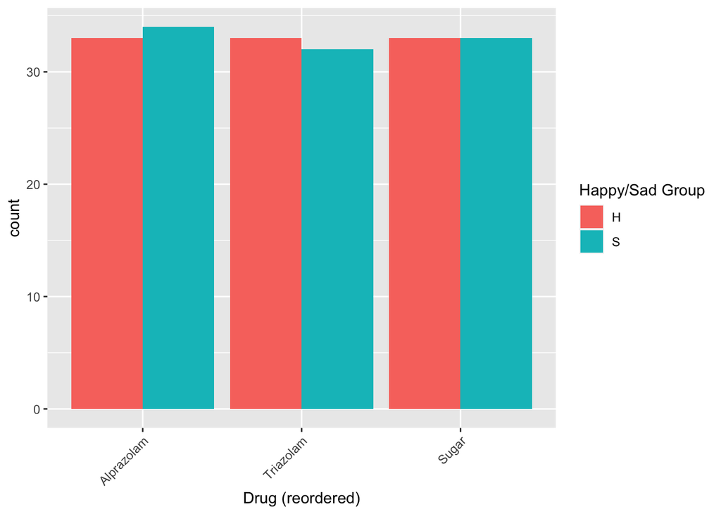

```r
# Create a bar plot of the reordered Drug and Happy_Sad_group variables
bar_plot_reordered <- ggplot(Isd_reordered, aes(x = Drug_reordered, fill = Happy_Sad_group)) +
  geom_bar(position = "dodge") +
  labs(x = "Drug (reordered)", fill = "Happy/Sad Group") +
  theme(axis.text.x = element_text(angle = 45, hjust = 1))

bar_plot_reordered
```

In this plot, we used the refactored and reordered `Drug` variable to create a more informative visualization. By refactoring and reordering factor variables, you can enhance the readability and effectiveness of your plots.

## Enhancing Plots with Titles, Axis Labels, Limits, and Themes

Adding titles, axis labels, limits, and customizing the theme can make your plots more informative and visually appealing. In this section, we will demonstrate how to enhance a plot using these features.

Let’s create a scatter plot of **`Sepal.Length`** vs **`Sepal.Width`** and use the **`Petal.Length`** column for color scaling in the **`iris`** dataset:

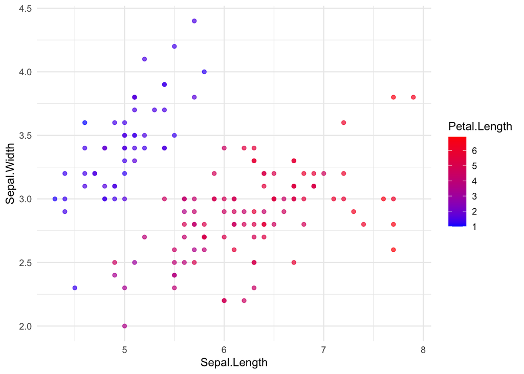

```r
# Create a scatter plot of Sepal.Length vs Sepal.Width and use Petal.Length for color scaling
scatter_plot_example <- ggplot(iris, aes(x = Sepal.Length, y = Sepal.Width, color = Petal.Length)) +
  geom_point(alpha = 0.7) +
  scale_color_continuous(low = "blue", high = "red") +
  theme_minimal()

scatter_plot_example
```

### Adding Title and Axis Labels

You can add a main title, subtitle, and axis labels using the `labs()` function:

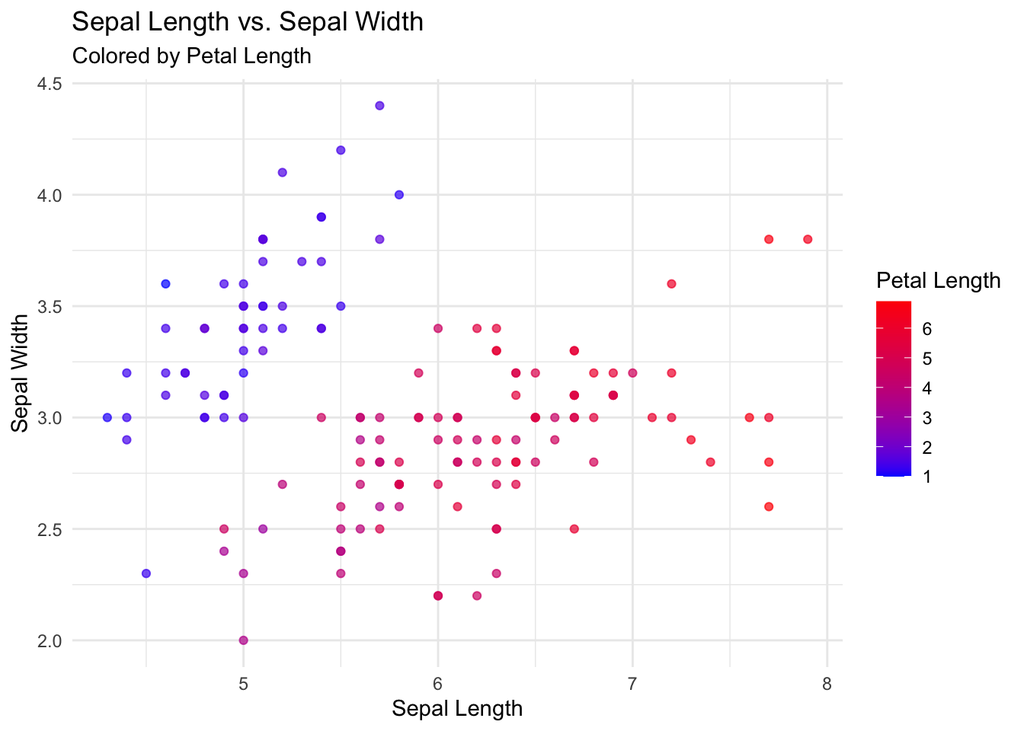

```r
# Add a main title, subtitle, and axis labels
scatter_plot_labeled <- scatter_plot_example +
  labs(
    title = "Sepal Length vs. Sepal Width",
    subtitle = "Colored by Petal Length",
    x = "Sepal Length",
    y = "Sepal Width",
    color = "Petal Length"
  )

scatter_plot_labeled
```

### Setting Axis Limits

To set the limits for the x and y axes, you can use the `xlim()` and `ylim()` functions:

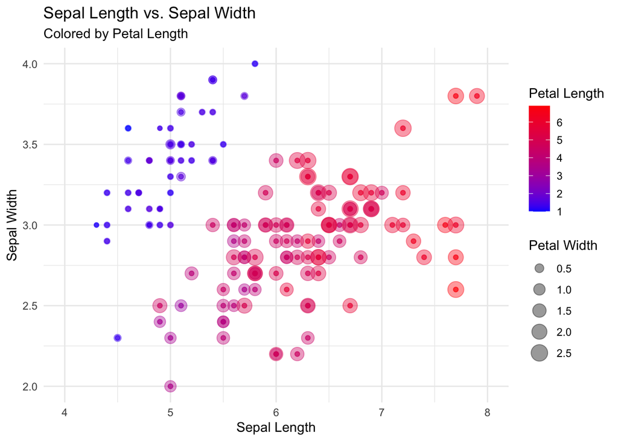

```r
# Set the limits for the x and y axes
scatter_plot_limited <- scatter_plot_labeled +
  xlim(4, 8) +
  ylim(2, 4) +
  geom_point(mapping = aes(size = Petal.Width), alpha=0.4) +
  labs(size = 'Petal Width')

scatter_plot_limited
```

### Customizing the Theme

You can customize the appearance of your plot by modifying the theme. The `theme()` function allows you to change various aspects of the plot, such as text size, font, background colors, and grid lines:

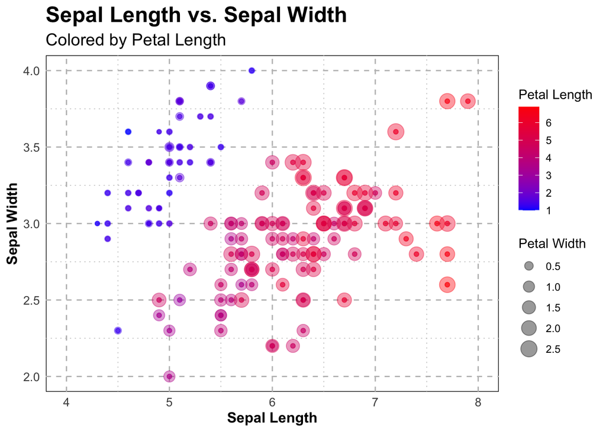

```r
scatter_plot_custom_theme <- scatter_plot_limited +
  theme(
    plot.title = element_text(size = 18, face = "bold"),
    plot.subtitle = element_text(size = 14),
    axis.title = element_text(size = 12, face = "bold"),
    axis.text = element_text(size = 10),
    panel.background = element_rect(fill = "white"),
    panel.grid.major = element_line(color = "gray", linetype = "dashed", linewidth = 0.5),
    panel.grid.minor = element_line(color = "gray", linetype = "dotted", linewidth = 0.25)
  )

scatter_plot_custom_theme
```

By adding titles, axis labels, limits, and customizing the theme, you can create more informative and visually appealing plots that effectively communicate your data’s story. See [cheatsheet](https://www.maths.usyd.edu.au/u/UG/SM/STAT3022/r/current/Misc/data-visualization-2.1.pdf) for additional themes.

## Exporting and Saving Plots with ggsave

`ggsave()` is a convenient function for saving your ggplot2 plots in various file formats, such as PNG, PDF, SVG, or TIFF. Using `ggsave()`, you can easily save high-quality versions of your plots for use in reports, presentations, or publications.

To save this plot as a high-quality PNG image, you can use the `ggsave()` function:

```r
# Save the plot as a PNG file
ggsave(
  filename = "scatter_plot_example.png",
  plot = scatter_plot_limited,
  width = 8,
  height = 5,
  dpi = 300
)
```

To save the plot in a different file format, you can change the file extension in the `filename` parameter. For example, to save the plot as a PDF, you can use:

```r
# Save the plot as a PDF file
ggsave(
  filename = "scatter_plot_example.pdf",
  plot = scatter_plot_custom_theme,
  width = 8,
  height = 5
)
```

By using `ggsave()`, you can easily export and save your ggplot2 plots in a variety of file formats to share or include in your documents.

## Combining Multiple Plots with patchwork

The `patchwork` package allows you to easily combine multiple ggplot2 plots into a single layout. This can be useful for comparing different visualizations side by side or creating more complex visualizations.

First, let’s create some example plots using the `mtcars` dataset:

```r
# Load the required packages
library(ggplot2)
library(patchwork)

# Create a scatter plot of mpg vs. wt
scatter_plot <- ggplot(mtcars, aes(x = wt, y = mpg)) +
  geom_point(aes(color = cyl)) +
  labs(title = "Miles per Gallon vs. Weight", x = "Weight (1000 lbs)", y = "Miles per Gallon", color = "Cylinders") +
  theme_minimal()

# Create a bar plot of the number of cars per number of cylinders
bar_plot <- ggplot(mtcars, aes(x = factor(cyl))) +
  geom_bar(aes(fill = factor(cyl))) +
  labs(title = "Number of Cars per Number of Cylinders", x = "Number of Cylinders", y = "Count", fill = "Cylinders") +
  theme_minimal()

# Create a box plot of mpg per number of cylinders
box_plot <- ggplot(mtcars, aes(x = factor(cyl), y = mpg)) +
  geom_boxplot(aes(fill = factor(cyl))) +
  labs(title = "Miles per Gallon per Number of Cylinders", x = "Number of Cylinders", y = "Miles per Gallon", fill = "Cylinders") +
  theme_minimal() # + theme(legend.position = "None")
```

Now, let’s use the `patchwork` package to combine these plots:

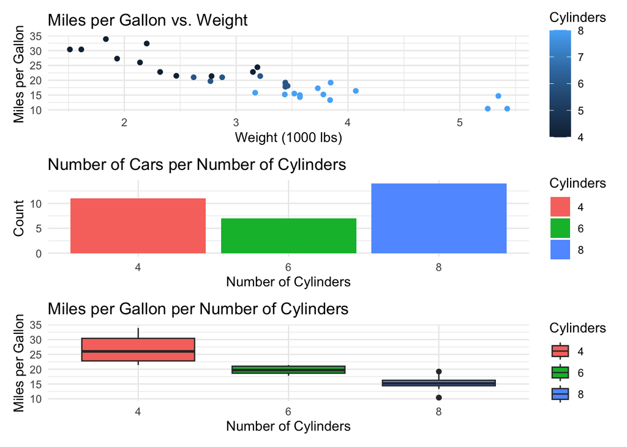

```r
# Combine the plots using patchwork
combined_plot <- scatter_plot + bar_plot + box_plot + plot_layout(ncol = 1)
combined_plot
```

In this example, we combined the three plots into a single column layout. You can adjust the layout by changing the `ncol` and `nrow` parameters in the `plot_layout()` function.

To collect the legends and add a global title, subtitle, and caption, you can use the `plot_annotation()` function:

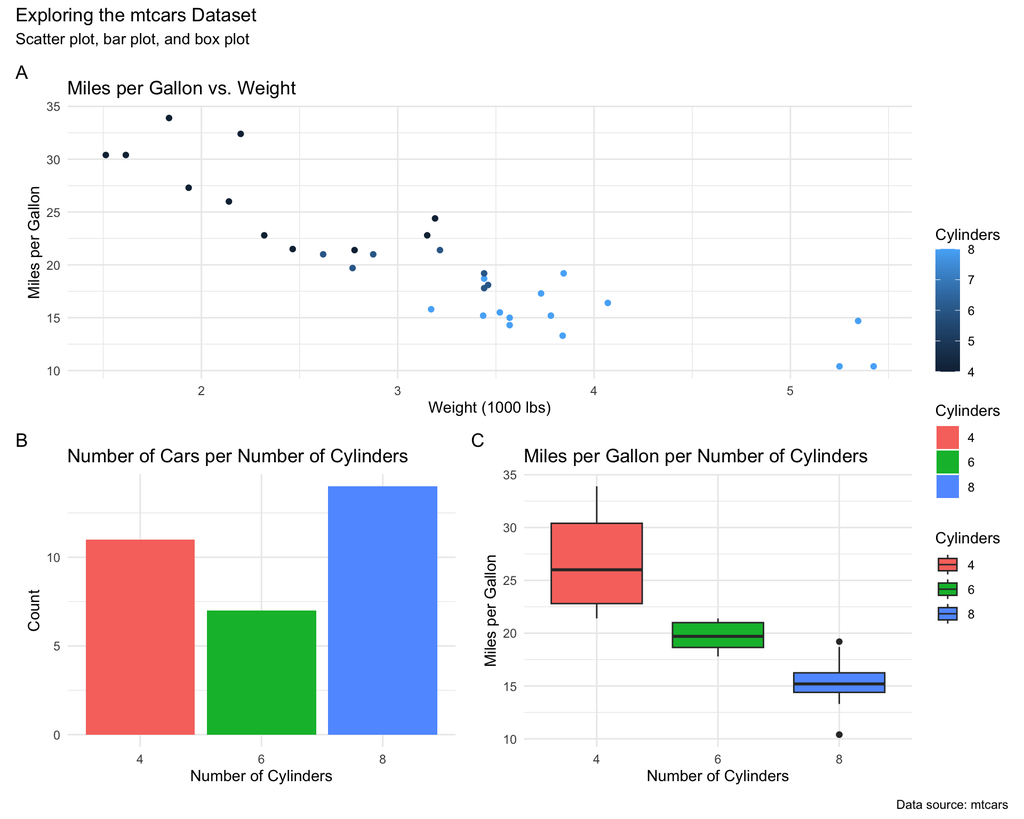

```r
# Collect legends and add global title, subtitle, and caption
combined_plot_annotated <- scatter_plot / (bar_plot + box_plot) +
  plot_annotation(
    title = "Exploring the mtcars Dataset",
    subtitle = "Scatter plot, bar plot, and box plot",
    caption = "Data source: mtcars",
    tag_levels = 'A'
  ) +
  plot_layout(guides = "collect")

combined_plot_annotated
```

By using the `patchwork` package, you can combine multiple ggplot2 plots into a single layout, making it easier to compare and present your visualizations.

### Task:

Now it’s your time to shine. Let you imagination fly and explore the Islander example dataset. Come up with your own visualisation. Use as many plots, as many colours and themes as you see fit. Start building it gradually, this makes finding and identifying errors easier. You can even take your own data and explore it. But try to get to a publishing ready image (*sans* figure legend).

Find more options from [data-wrangling-cheatsheet](https://www.rstudio.com/wp-content/uploads/2015/02/data-wrangling-cheatsheet.pdf).